# Beesim Report

# Results

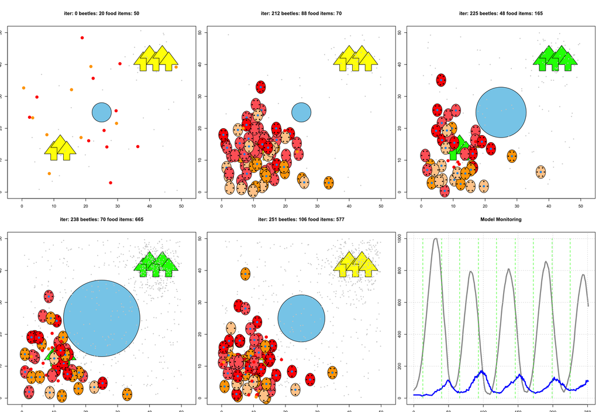

## Stability of the above results across repeated simulations

Population of Beetles in Last Seaseon

| Run | Dry Season | Wet Season |
| --- | --- | --- |
| 1 | 113 | 49 |
| 2 | 105 | 85 |
| 3 | 112 | 65 |
| 4 | 81 | 84 |
| 5 | 45 | 9 |

Summary of Beetles Population

|  | Dry Season | Wet Season |
| --- | --- | --- |
| Max | 113.00 | 85.00 |
| Min | 45.00 | 9.00 |
| Median | 105.00 | 65.00 |
| Mean | 91.20 | 58.40 |
| SD | 28.88 | 31.37 |

# Discussion

The oscillation in the beetle population has a period matching the season and a shift in the curve of about half a season compared to the food curve. This result strongly resembles that of a predator-prey-relationship modeled by the Lotka-Volterra-equations. In such a model, the increase in the “prey population”, here the amount of available food, is linearly dependent to its own size but the decrease is linearly dependent on both the size of its own as well as the predator population. The growth of the predator population is positively linearly correlated to its own size as well as that of the prey population, and negatively linearly correlated to the size of the prey population. While in our model the decrease in food is (in part) dependent on the number of beetles, the “creation” of food is not. Instead it correlates to the seasons, giving it is sinus-shaped curve. The size of the beetle population is only indirectly dependent on the amount of food insofar as beetles might starve (decreasing population size) and can only reproduce when they have eaten enough. This adds an element of randomness to the model that the Lotka-Volterra-equations lack. It seems that the Monte-Carlo-Simulation is a stochastic alternative to modeling the predator-prey-relationship deterministically using the Lotka-Volterra-equations.

The beetle population in our model is also decreased when beetles drown in the lake. While the size of the lake and therefore the likeliness of beetles drowning is not dependent on the amount of food, it is dependent on the season. During the wet season, when there is increased food regrowing, the lake area increases while during the dry season, when food regrowing is rarer, the lake area diminishes. So there are contradictory effects on the beetle population during each season (either a large food supply and a maximal lake area or a smaller food supply and a minimal lake area). We can conclude that (given the parameters used for our model) the amount of available food is affecting the beetle population more strongly since the beetle population grows with the food supply. This effect is somewhat delayed since the beetles have to “find” and eat the food first and then “find” a mate and reproduce. If the effect of the lake size increase was more impactful than the food supply, the numbers of beetles would decrease simultaneously with the lake size, i.e. with the passing of the wet season.

Overall, the MCS proved to be suitable for modeling beetle population dynamics. It allows for easy extensions to include additional factors in an already existing model and is more versatile and less computationally intense than the Lotka-Volterra-equations that focus primarily on predator-prey-relationships and require differential equations to be solved. However, it could not provide a definite answer as to how a beetle population will develop under the chosen parameters given the wide span between possible outcomes and the high standard deviation. This might be solved by more runs over more iterations to create a more statistically sound result but it could also simply be due to the randomness inherent to the MCS model.

# Literature

Bermúdez, Jordi, Daniel López, Joaquim Valls, and Jorge Wagensberg. 1989. “On the Analysis of Microbiological Processes by Monte Carlo Simulation Techniques.” *Bioinformatics* 5 (4): 305–12.

Charlebois, Daniel A, and Gábor Balázsi. 2019. “Modeling Cell Population Dynamics.” *In Silico Biology* 13 (1-2): 21–39.

De-Leon, Hilla, and Dvir Aran. 2023. “MAM: Flexible Monte-Carlo Agent Based Model for Modelling COVID-19 Spread.” *Journal of Biomedical Informatics* 141: 104364.

Foffi, G, A Pastore, Federico Piazza, and PA Temussi. 2013. “Macromolecular Crowding: Chemistry and Physics Meet Biology (Ascona, Switzerland, 10–14 June 2012).” *Physical Biology* 10 (4): 040301.

Fullman, Timothy J, Benjamin K Sullender, Matthew D Cameron, and Kyle Joly. 2021. “Simulation Modeling Accounts for Uncertainty While Quantifying Ecological Effects of Development Alternatives.” *Ecosphere* 12 (5): e03530.

Kakoullis, Loukas, Robert Steffen, Albert Osterhaus, Marco Goeijenbier, Sowmya R Rao, Satoshi Koiso, Emily P Hyle, Edward T Ryan, Regina C LaRocque, and Lin H Chen. 2023. “Influenza: Seasonality and Travel-Related Considerations.” *Journal of Travel Medicine* 30 (5): taad102.

Lau, Samantha, Aljosa Trmcic, NH Martin, Martin Wiedmann, and SI Murphy. 2022. “Development of a Monte Carlo Simulation Model to Predict Pasteurized Fluid Milk Spoilage Due to Post-Pasteurization Contamination with Gram-Negative Bacteria.” *Journal of Dairy Science* 105 (3): 1978–98.

Maltezos, Stavros, and Angelika Georgakopoulou. 2021. “Novel Approach for Monte Carlo Simulation of the New COVID-19 Spread Dynamics.” *Infection, Genetics and Evolution* 92: 104896.

Marini, Giovanni, Piero Poletti, Mario Giacobini, Andrea Pugliese, Stefano Merler, and Roberto Rosà. 2016. “The Role of Climatic and Density Dependent Factors in Shaping Mosquito Population Dynamics: The Case of Culex Pipiens in Northwestern Italy.” *PLoS One* 11 (4): e0154018.

Michael, Eleni, and Thomas Simonson. 2022. “How Much Can Physics Do for Protein Design?” *Current Opinion in Structural Biology* 72: 46–54.

Montville, Rebecca, and Donald Schaffner. 2005. “Monte Carlo Simulation of Pathogen Behavior During the Sprout Production Process.” *Applied and Environmental Microbiology* 71 (2): 746–53.

Sinha, Saptarshi, Rajdeep Kaur Grewal, and Soumen Roy. 2020. “Modeling Phage–Bacteria Dynamics.” *Immunoinformatics*, 309–27.

Solé, Ricard V, and Joaquim Valls. 1992. “Nonlinear Phenomena and Chaos in a Monte Carlo Simulated Microbial Ecosystem.” *Bulletin of Mathematical Biology* 54: 939–55.

Triambak, S, and DP Mahapatra. 2021. “A Random Walk Monte Carlo Simulation Study of COVID-19-Like Infection Spread.” *Physica A: Statistical Mechanics and Its Applications* 574: 126014.